# Reproducible Research: Peer Assessment 1

Max Reimerson

## Loading and preprocessing the data

Show any code that is needed to

Load the data (i.e. read.csv())

Process/transform the data (if necessary) into a format suitable for your analysis

```r
# Unzip and read the csv file
raw_data <- read.csv(unz("activity.zip", "activity.csv"))
# Remove any na in the ds
clean_data <- raw_data[complete.cases(raw_data),]
```

## What is mean total number of steps taken per day?

For this part of the assignment, you can ignore the missing values in the dataset.

1. Calculate the total number of steps taken per day

```r
library(dplyr)
# Group by date and sum steps
daily_steps <- group_by(clean_data, date) %>% summarise(steps = sum(steps))
```

2. If you do not understand the difference between a histogram and a barplot, research the difference between them. Make a histogram of the total number of steps taken each day

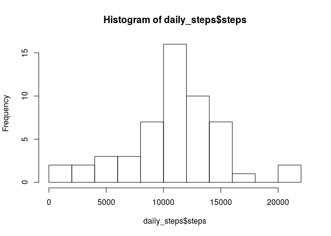

```r
hist(daily_steps$steps, breaks = 10)
```

3. Calculate and report the mean and median of the total number of steps taken per day.

Mean is:

```r
mean(daily_steps$steps)
```

```
## [1] 10766.19
```

Median is:

```r
median(daily_steps$steps)
```

```
## [1] 10765
```

## What is the average daily activity pattern?

1. Make a time series plot (i.e. type=“l”) of the 5-minute interval (x-axis) and the average number of steps taken, averaged across all days (y-axis) library(dplyr)

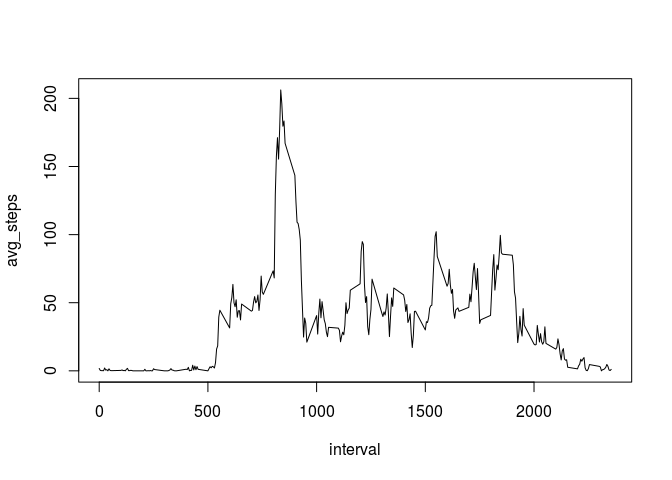

```r
# Group it by interval and take the mean
interval_steps <- group_by(clean_data, interval) %>% summarise(avg_steps = mean(steps))
plot(interval_steps, type="l")
```

2. Which 5-minute interval, on average across all the days in the dataset, contains the maximum number of steps?

```r
arrange(interval_steps, desc(avg_steps))[1,]
```

```
## # A tibble: 1 x 2
##   interval avg_steps
##      <int>     <dbl>
## 1      835      206.
```

## Imputing missing values

Note that there are a number of days/intervals where there are missing values (coded as NA). The presence of missing days may introduce bias into some calculations or summaries of the data.

1. Calculate and report the total number of missing values in the dataset (i.e. the total number of rows with NAs)

```r
sum(is.na(raw_data$steps))
```

```
## [1] 2304
```

2. Devise a strategy for filling in all of the missing values in the dataset. The strategy does not need to be sophisticated. For example, you could use the mean/median for that day, or the mean for that 5-minute interval, etc.

*Here I use a simple strategy of taking the avg number of steps per interval as calculated earlier.*

```r
# Use the average by interval calculated earlier
joined_ds <- merge(raw_data, interval_steps, by='interval', all.x = TRUE, all.y = FALSE)
```

3. Create a new dataset that is equal to the original dataset but with the missing data filled in.

```r
imputed_ds <- joined_ds

# If the steps is na then use the calculated average by interval
imputed_ds$steps <- ifelse(is.na(imputed_ds$steps), imputed_ds$avg_steps, imputed_ds$steps)
imputed_ds <- imputed_ds[-4]
```

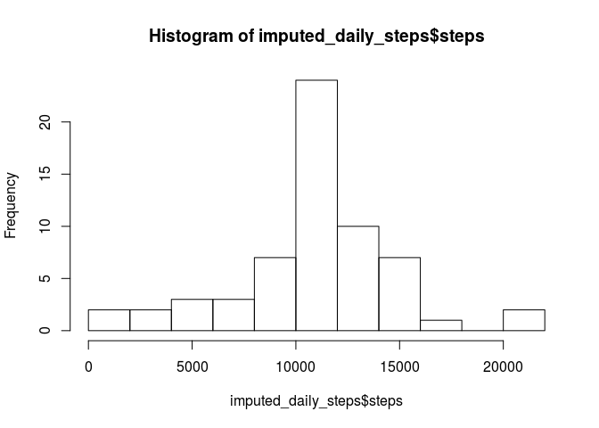

```r
# Calculate total number of steps per day
imputed_daily_steps <- group_by(imputed_ds, date) %>% summarise(steps = sum(steps))
hist(imputed_daily_steps$steps, breaks = 10)
```

```r
mean(imputed_daily_steps$steps)
```

```
## [1] 10766.19
```

```r
median(daily_steps$steps)
```

```
## [1] 10765
```

## Are there differences in activity patterns between weekdays and weekends?

For this part the weekdays() function may be of some help here. Use the dataset with the filled-in missing values for this part.

1. Create a new factor variable in the dataset with two levels – “weekday” and “weekend” indicating whether a given date is a weekday or weekend day.

```r
imputed_ds_day_type <- imputed_ds
# Convert to Posix dates, take the weekday and check if its a saturday or sunday
imputed_ds_day_type$day_type <- ifelse(weekdays(as.POSIXct(imputed_ds_day_type$date)) %in% c('Saturday', 'Sunday'), 'weekend', 'weekday')
```

2. Make a panel plot containing a time series plot (i.e. type=“l”) of the 5-minute interval (x-axis) and the average number of steps taken, averaged across all weekday days or weekend days (y-axis). See the README file in the GitHub repository to see an example of what this plot should look like using simulated data.

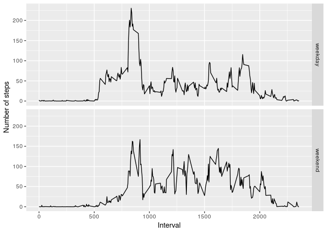

```r
library(ggplot2)
# Group by type of day and interval and take an average
interval_daytype_steps <- group_by(imputed_ds_day_type, day_type, interval) %>% summarise(avg_steps = mean(steps))

ggplot(interval_daytype_steps, aes(x = interval, y=avg_steps)) + facet_grid(rows = vars(day_type)) + geom_line() + xlab('Interval') + ylab('Number of steps')
```